# BigHole River — Melrose Section

Brown Trout IPM — Streamflow Effects on Population Dynamics

Montana Fisheries Analysis

May 21, 2026

# About This Project

This report summarizes a Bayesian integrated population model (IPM) quantifying how streamflow and drought conditions influence brown trout population dynamics across Montana river sections. For each site, the model evaluates how seasonal (summer and winter) flows — at various time lags — affect recruitment and adult survival, then selects the best-supported flow structure via Bayesian indicator variable selection. Results below show the selected model, parameter estimates, fitted flow–response relationships, and the proportion of recruitment and survival variance explained by flow.

# Site Overview

| **River** | BigHole |
| --- | --- |
| **Section** | Melrose |
| **Model structure** | Global (Summer + Winter) |
| **Sub-models present** | Global (Summer + Winter) |
| **Year range** | 1991 – 2026 |
| **N lag combinations evaluated** | 9 |

# Model Selection Summary

The table below shows the top-selected flow structure — that is, the combination of summer and winter flow lags (and quadratic vs. linear shape) with the highest posterior inclusion probability. Full model-selection details (lag inclusion probabilities, joint lag heatmap, quadratic-term panels, and the complete combinations table) are provided in the **Appendix**.

Best lag and quadratic structure — BigHole.Melrose

| Sub-model | Top Summer Lag | Top Winter Lag | Lag Inclusion Pr. | Sum Rec Quad | Sum Surv Quad | Win Rec Quad | Win Surv Quad | Quad Combo Pr. |
| --- | --- | --- | --- | --- | --- | --- | --- | --- |
| Global (Summer + Winter) | 2 | 2 | 0.1822 | no | no | no | no | 0.1189 |

# Key Findings

## Model Summary

Bayesian age-structured integrated population model (IPM) fit to brown trout electrofishing data at the **BigHole River — Melrose section** (1991–2026). Flow covariates were standardised (Z-scored log-flow) prior to model fitting. Parameter directions and magnitudes reported below are based on the posterior distribution of the top-selected model; see Sections 4–7 for full posterior summaries and plots.

[figure not shown]

[output not shown]

Flow covariates (Flow) are Z-scored log-flow: Flow = (log(flow) − μ) / σ. Terms excluded by indicator variable selection are omitted from fitted model equations in Sections 4–7. Solid arrows = deterministic transitions; dashed = covariate effects; orange dashes = survival applied to age transitions.

## Summer Flow and Recruitment

Summer mean flow at lag **2 years prior** had a **positive** effect on recruitment, modelled as a linear relationship (b1r = 0.252).

## Winter Flow and Recruitment

Winter mean flow at lag **2 years prior** had a **positive** effect on recruitment, modelled as a linear relationship (b5r = 0.237). Effects on age-2 recruitment are not detectable in survey data until **2 years prior**, reflecting the time from egg deposition to age-2 detection.

## Seasonal Flow and Adult Survival

Summer flow had a **weak or uncertain** effect on logit-survival, modelled as a linear relationship (b1S = 0.038).

Winter flow had a **negative** effect on logit-survival, modelled as a linear relationship (b5S = -0.327).

## Density Dependence in Survival

The density-dependent survival parameter (b6S) was **negative** (median = -0.0701), indicating that annual survival declines with increasing total abundance.

## Flow Explained Variance and Biomass Trend

The top flow model (summer flow at lag 2 years prior; winter flow at lag 2 years prior) accounts for **6.8%** of residual recruitment variance and **2.5%** of residual survival variance relative to a null (no-flow) model. Total biomass over the study period showed **a declining trend (~5656.3 g/yr)**.

# 1. Abundance Time Series

Age-specific abundance (N2 = age-2 recruits, N3 = age-3, N4 = age-4+). Shaded bands = 90% credible intervals.

Display: Age-2 Age-3 Age-4+ Total

Flow Overlay:

Summer

Winter

[interactive chart not shown]

# 2. Survival Time Series

Annual survival probability (0–1 scale). Shaded band = 90% CrI.

Flow Overlay:

Summer

Winter

[interactive chart not shown]

# 3. Ricker Recruitment Model Parameters

Log-linear Ricker stock–recruitment relationship: log(R) = log(α) + log(S) − β·S + flow effects − σ²_R/2, where S = spawner abundance and flow is standardised.

Ricker recruitment model parameters — BigHole.Melrose

| Parameter | Median | 90% CrI |
| --- | --- | --- |
| log(α) [la0] | -7.086000 | [-7.422, -6.573] |
| β (density, per spawner) [b] | 0.000001 | [0, 3e-06] |
| σ_R [sigmaR] | 0.825000 | [0.684, 1.013] |
| Q (catchability) | 0.763000 | [0.698, 0.835] |
| Summer flow (linear) [b1r] | 0.252000 | [0.049, 0.455] |
| Winter flow (linear) [b5r] | 0.237000 | [0.007, 0.47] |

# 4. Flow Effects on Recruitment

Posterior distributions for flow effects on log-recruitment.

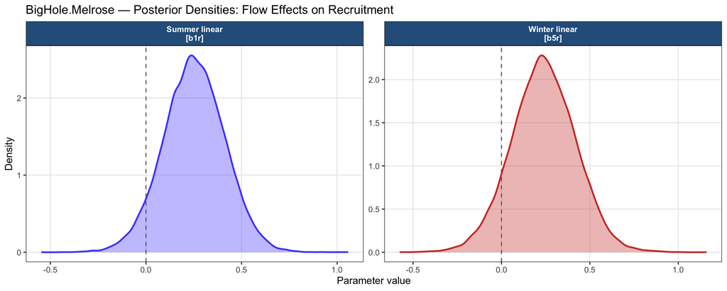

# 4b. Simulated Ricker Recruitment Curves

Recruitment as a function of spawner stock biomass (SSB) simulated across three standardised summer flow scenarios (flow = −2, 0, +2 SD), holding all other parameters at their posterior medians. Shaded envelopes show 90% credible intervals propagated across the full posterior. The lognormal bias correction (−σ²_R / 2) is applied so curves represent expected median recruitment.

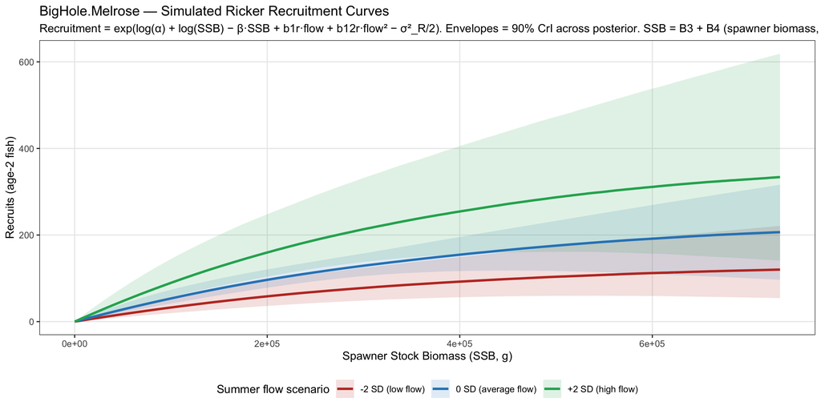

# 4c. Observed Flow–Recruitment Relationship

Each point is one year’s estimated log(Recruits/Spawners) plotted against the observed (back-transformed) summer or winter flow for that year at the top selected lag. The blue line is the posterior median fitted relationship; the grey band is the 90% credible interval. Red points are years where log(R/S) fell below −1 (poor recruitment). The vertical dashed red line marks the flow value where the fitted curve crosses log(R/S) = 0 (replacement); where that crossing exists, the subtitle reports the range.

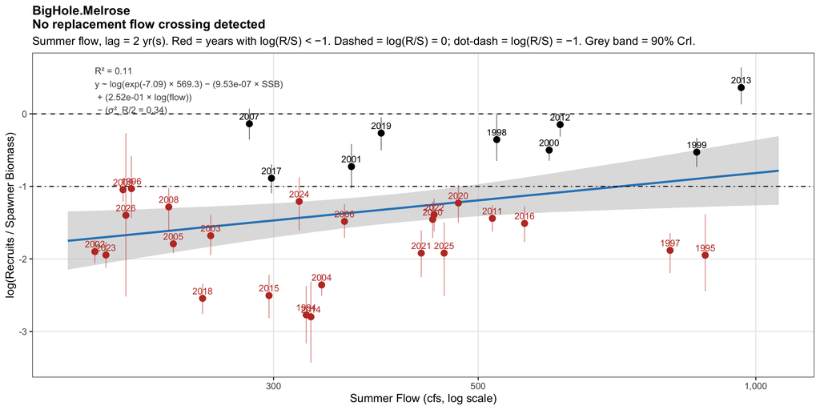

# 5. Flow Effects on Survival

Posterior distributions for flow and density effects on logit-survival.

Flow & density effects on survival — BigHole.Melrose

| Parameter | Median | 90% CrI |
| --- | --- | --- |
| Summer flow (linear) [b1S] | 0.038 | [-0.25, 0.324] |
| Winter flow (linear) [b5S] | -0.327 | [-0.633, -0.031] |
| Density dependence [b6S] | -0.070 | [-0.166, 0.016] |
| Intercept logit-surv [lSurv0] | 1.606 | [0.973, 2.347] |
| σ_Surv [sigmaSurv] | 0.975 | [0.743, 1.301] |

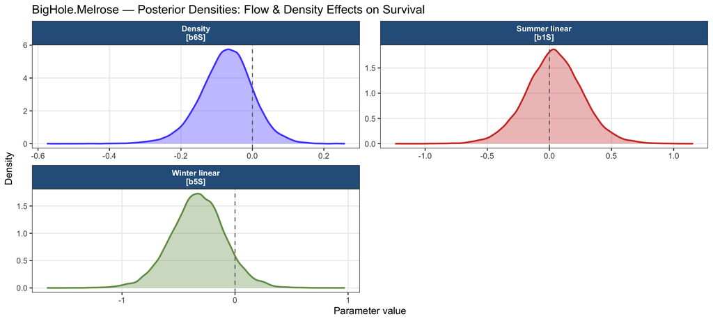

# 5b. Observed Flow–Survival Relationship

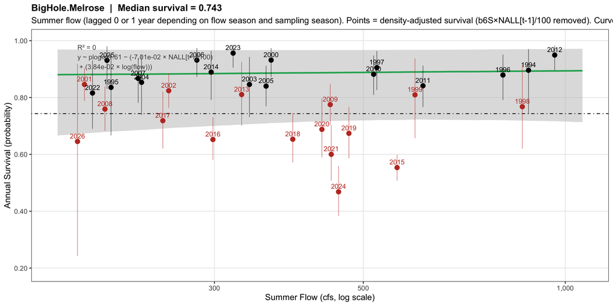

# 6. Explained Residual Variance

Proportion of residual variance in recruitment (σ_R) and survival (σ_Surv) explained by the flow model relative to a null (no-flow) model.

**Formula:** Explained variance = 1 − (σ_flow / σ_null)

Positive values indicate the flow model reduces unexplained variation; negative values indicate the flow model inflates it.

Explained residual variance — flow vs. null model — BigHole.Melrose

| Parameter | Median | 90% CrI |
| --- | --- | --- |
| Recruitment (σ_R) | 0.068 | [-0.227, 0.291] |
| Survival (σ_Surv) | 0.025 | [-0.458, 0.35] |

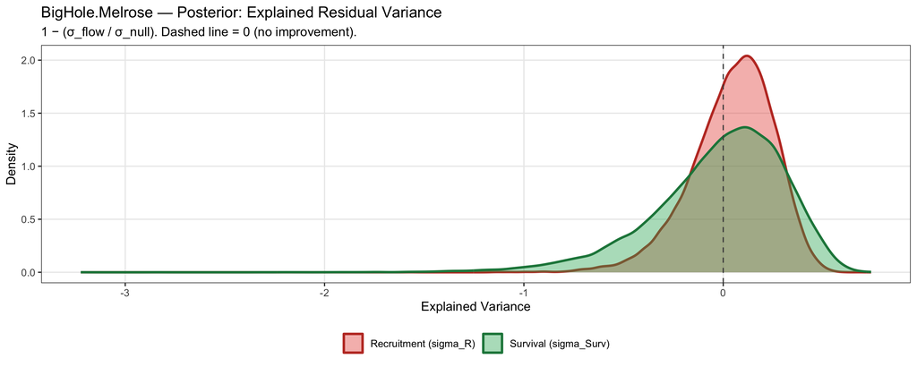

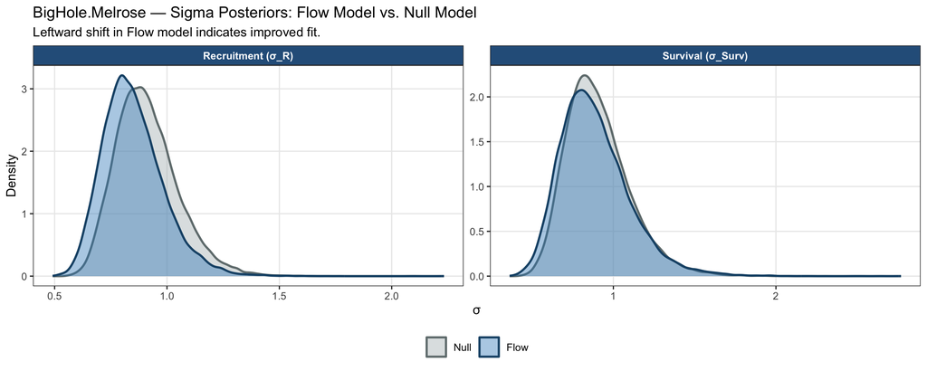

# Appendix: Full Model Selection Details

This appendix documents the full model-selection process used to arrive at the top-selected flow structure reported above. The IPM was fit repeatedly across all candidate flow-lag combinations and linear/quadratic shape combinations for each demographic process (recruitment and survival). Bayesian indicator variables track how often each lag and each quadratic term is included in the posterior, providing a natural measure of support.

## Lag Inclusion Probabilities

Posterior probability that each candidate flow lag is included in the model, by sub-model type. Bars to the right of the dashed line indicate support greater than the equal prior probability; the selected top lag for each sub-model is highlighted.

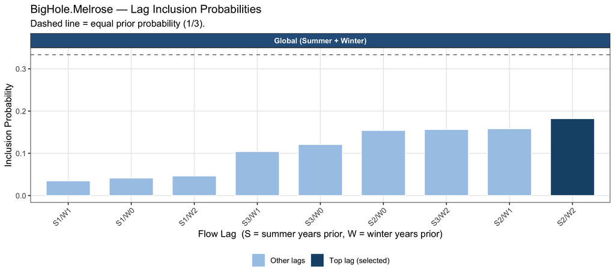

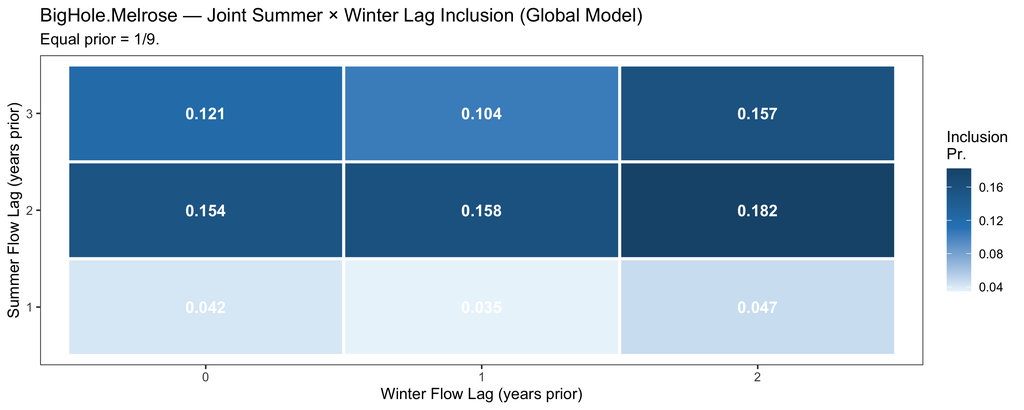

## Quadratic Term Inclusion — All Lag Combinations

These panels show the probability of preferring a quadratic over a linear flow–response for each demographic process, across every evaluated lag combination. Points are shaded by lag inclusion probability; the red-bordered point marks the top-selected lag for that sub-model.

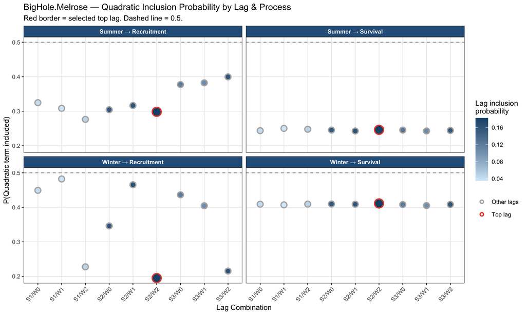

## Full Inclusion Probability Table

All lag/quadratic combinations — BigHole.Melrose

| Sub-model | Summer Lag | Winter Lag | Lag Pr. | Sum Rec Q | Sum Surv Q | Win Rec Q | Win Surv Q | Quad Combo Pr. | Q Pr Sum Rec | Q Pr Win Rec | Q Pr Sum Surv | Q Pr Win Surv |
| --- | --- | --- | --- | --- | --- | --- | --- | --- | --- | --- | --- | --- |
| Global (Summer + Winter) | 2 | 2 | 0.1822 | no | no | no | no | 0.1189 | 0.298 | 0.195 | 0.246 | 0.411 |
| Global (Summer + Winter) | 2 | 2 | 0.1822 | no | no | no | yes | 0.0844 | 0.298 | 0.195 | 0.246 | 0.411 |
| Global (Summer + Winter) | 2 | 2 | 0.1822 | yes | no | no | no | 0.0509 | 0.298 | 0.195 | 0.246 | 0.411 |
| Global (Summer + Winter) | 2 | 2 | 0.1822 | no | yes | no | no | 0.0380 | 0.298 | 0.195 | 0.246 | 0.411 |
| Global (Summer + Winter) | 2 | 2 | 0.1822 | yes | no | no | yes | 0.0339 | 0.298 | 0.195 | 0.246 | 0.411 |
| Global (Summer + Winter) | 2 | 2 | 0.1822 | no | no | yes | no | 0.0280 | 0.298 | 0.195 | 0.246 | 0.411 |
| Global (Summer + Winter) | 2 | 2 | 0.1822 | no | yes | no | yes | 0.0272 | 0.298 | 0.195 | 0.246 | 0.411 |
| Global (Summer + Winter) | 2 | 2 | 0.1822 | no | no | yes | yes | 0.0188 | 0.298 | 0.195 | 0.246 | 0.411 |
| Global (Summer + Winter) | 2 | 2 | 0.1822 | yes | yes | no | no | 0.0160 | 0.298 | 0.195 | 0.246 | 0.411 |
| Global (Summer + Winter) | 2 | 2 | 0.1822 | yes | no | yes | no | 0.0130 | 0.298 | 0.195 | 0.246 | 0.411 |
| Global (Summer + Winter) | 2 | 2 | 0.1822 | yes | yes | no | yes | 0.0114 | 0.298 | 0.195 | 0.246 | 0.411 |
| Global (Summer + Winter) | 2 | 2 | 0.1822 | no | yes | yes | no | 0.0094 | 0.298 | 0.195 | 0.246 | 0.411 |
| Global (Summer + Winter) | 2 | 2 | 0.1822 | yes | no | yes | yes | 0.0087 | 0.298 | 0.195 | 0.246 | 0.411 |
| Global (Summer + Winter) | 2 | 2 | 0.1822 | no | yes | yes | yes | 0.0072 | 0.298 | 0.195 | 0.246 | 0.411 |
| Global (Summer + Winter) | 2 | 2 | 0.1822 | yes | yes | yes | no | 0.0042 | 0.298 | 0.195 | 0.246 | 0.411 |
| Global (Summer + Winter) | 2 | 2 | 0.1822 | yes | yes | yes | yes | 0.0029 | 0.298 | 0.195 | 0.246 | 0.411 |
| Global (Summer + Winter) | 2 | 1 | 0.1584 | no | no | no | no | 0.0884 | 0.317 | 0.465 | 0.243 | 0.409 |
| Global (Summer + Winter) | 2 | 1 | 0.1584 | no | no | yes | no | 0.0753 | 0.317 | 0.465 | 0.243 | 0.409 |
| Global (Summer + Winter) | 2 | 1 | 0.1584 | no | no | no | yes | 0.0615 | 0.317 | 0.465 | 0.243 | 0.409 |
| Global (Summer + Winter) | 2 | 1 | 0.1584 | no | no | yes | yes | 0.0505 | 0.317 | 0.465 | 0.243 | 0.409 |
| Global (Summer + Winter) | 2 | 1 | 0.1584 | yes | no | no | no | 0.0391 | 0.317 | 0.465 | 0.243 | 0.409 |
| Global (Summer + Winter) | 2 | 1 | 0.1584 | yes | no | yes | no | 0.0364 | 0.317 | 0.465 | 0.243 | 0.409 |
| Global (Summer + Winter) | 2 | 1 | 0.1584 | yes | no | no | yes | 0.0275 | 0.317 | 0.465 | 0.243 | 0.409 |
| Global (Summer + Winter) | 2 | 1 | 0.1584 | no | yes | no | no | 0.0268 | 0.317 | 0.465 | 0.243 | 0.409 |
| Global (Summer + Winter) | 2 | 1 | 0.1584 | no | yes | yes | no | 0.0244 | 0.317 | 0.465 | 0.243 | 0.409 |
| Global (Summer + Winter) | 2 | 1 | 0.1584 | yes | no | yes | yes | 0.0242 | 0.317 | 0.465 | 0.243 | 0.409 |
| Global (Summer + Winter) | 2 | 1 | 0.1584 | no | yes | no | yes | 0.0199 | 0.317 | 0.465 | 0.243 | 0.409 |
| Global (Summer + Winter) | 2 | 1 | 0.1584 | no | yes | yes | yes | 0.0167 | 0.317 | 0.465 | 0.243 | 0.409 |
| Global (Summer + Winter) | 2 | 1 | 0.1584 | yes | yes | no | no | 0.0122 | 0.317 | 0.465 | 0.243 | 0.409 |
| Global (Summer + Winter) | 2 | 1 | 0.1584 | yes | yes | yes | no | 0.0118 | 0.317 | 0.465 | 0.243 | 0.409 |

[output cut: 114 more lines]